# Understanding the Drivers of Player Market Value in FIFA 21

Valerio Gomez-Frittelli, Delaney Dvorsky, Kaylee Seo, Rishi Damarla

## Introduction

The global football transfer market is a multibillion-euro ecosystem in which player valuation shapes recruitment decisions, strategic planning, and competitive balance. Yet the factors that influence a player’s market value, ranging from demographic traits and positional demands to technical skills and league context, are complex and not always visible. Gaining a clearer understanding of these value drivers can offer meaningful insights for analysts, scouts, clubs, and fans seeking to interpret or predict how players are priced.

The goal of this project is to uncover patterns in how player characteristics relate to market value and to develop a more transparent understanding of what contributes to a player’s perceived worth. By analyzing a large-scale dataset of professional players, we aim to identify the demographic, positional, and technical attributes that most strongly influence valuation. This analysis not only enhances our understanding of player economics within the football world but also provides a structured foundation for more informed evaluation and comparison across players.

## Data Description

Our dataset comes from the FIFA 21 Complete Player Dataset on Kaggle, which includes data from FIFA 15 to FIFA 21. It contains 18,994 unique observations with 106 attributes. Each observation represents a single professional football player. For this project, we focus exclusively on the FIFA 21 edition of the dataset.

The dataset contains 18,000+ professional football players worldwide. The dataset contains 100+ attributes including:

- Demographic attributes: age, nationality, height, weight, preferred foot, and contract length.
- Market-related variables: player market value (in euros), wage, release clause, and club affiliation.
- Contextual variables: league and positions.
- Technical and physical skill ratings: dribbling, passing, shooting, defending, pace, physicality, and position-specific attribute groups.
- Overall and potential ratings: FIFA’s aggregate measures of current and projected player ability.

Below are the primary variables used in our analysis:

‘value_eur’: Player’s estimated market value, measured in euros (quantitative)

‘wage_eur’: Player’s wage, measured in euros (quantitative)

‘age’: Player’s age at the time of data collection (quantitative)

‘nationality’: Player’s nationality (categorical)

‘overall’: Player’s overall rating (0-100), summarizing general skill level (quantitative)

‘team_position’: Player’s position in the team

‘physic’: Player’s physicality score (0-100) (quantitative)

‘league_name’: The league in which the player competes (categorical)

Other FIFA metrics (quantitative): Detailed attribute ratings (0–100) covering attacking skills, passing, dribbling, movement, defending, mentality, and goalkeeper abilities.

This dataset offers the depth required to analyze valuation from demographic, contextual, and skill-based perspectives.

## Research Questions

Our project investigates the overarching question: What factors drive market value differences among professional football players in the FIFA 21 dataset?

To answer this, we structure our analysis around three guiding research questions:

1. **How do demographic characteristics relate to players’ market value in FIFA 21?** This includes examining age, nationality, and league to understand how a player’s background and career context influence their valuation. These characteristics can help us predict a player’s value without any knowledge of their on-field ability.
2. **How do player positional roles contribute to systematic differences in market valuation?** Here, we explore how teams’ positional wants and needs can systematically affect players’ valuation. Analysis of scarcity and demand accompany and help explain differences in value between positional groups.
3. **How well can we use technical and physical skill attributes to explain market value?** This question focuses on understanding how specific abilities and individual skill profiles contribute to valuation, including dimensionality reduction and attribute-level analysis.

## RQ1: Demographic Value Drivers

To examine how demographic characteristics relate to player market valuation, we first analyze how nationality corresponds to variation in market value. The choropleth maps below display the mean and median market values of players from each country in the FIFA21 dataset, including only nations with at least 20 players. The mean reflects superstar-driven effects (how a few elite players raise a country’s overall average), while the median represents the typical player’s value from that nation.

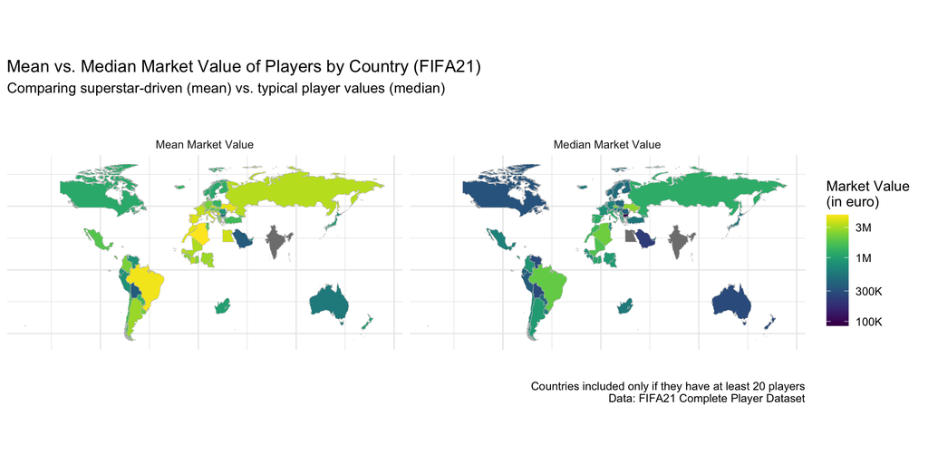

From these choropleth maps, we see clear geographic patterns in market valuation. European countries consistently appear among the highest-value regions in both mean and median terms, reflecting strong football infrastructure, competitive domestic leagues, and well-developed youth systems. Countries with globally recognized superstars, such as Brazil, Argentina, and Portugal, show especially elevated mean values, highlighting how a small number of elite players can disproportionately raise a nation’s average market value.

However, the median map provides a more accurate picture of general player depth. Several mid-sized European football nations, such as Croatia, Denmark, and Switzerland, exhibit relatively high median values despite having fewer superstar outliers. This suggests consistent talent quality rather than reliance on a few highly valued individuals.

In contrast, many regions across Africa, Asia, and Oceania display lower values in both mean and median metrics, pointing to broader disparities in developmental resources, league competitiveness, scouting exposure, and access to major transfer markets.

Overall, these choropleth maps demonstrate that nationality is a meaningful demographic driver of market valuation, with differences shaped by both superstar presence and the underlying depth of each country’s talent pool.

Age is an important factor for all athletes, and understanding how age affects a player’s value and interacts with other aspects of their game can give us great insights into what makes a player valuable. A popular question in football is how long some of the game’s superstars will continue to play. Understanding players’ longevity can be immensely useful in predicting their value; for example, a 30-year-old player who only has 1 year left might not carry nearly as much market value as a 30-year-old who will continue to play for 5 years. Further, it may well be the case that only the most elite or physically fit players have the longest careers. To investigate this important relationship, we can plot the distribution of players’ value grouped by their age and their physicality, as evaluated by FIFA’s physic metric.

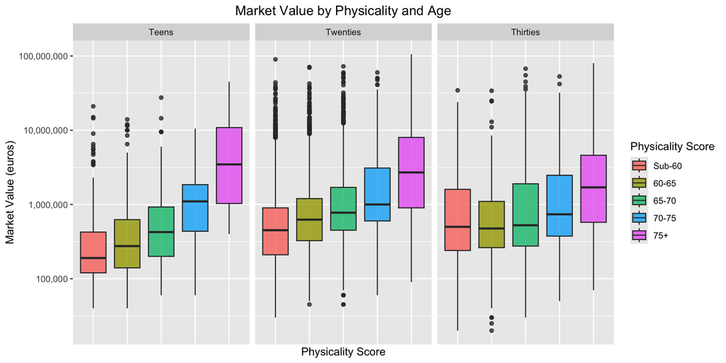

The plot shows, unsurprisingly, that players with higher physicality scores tend to have higher market value than players of a similar age and a lower physicality score. Football is a sport, and better athletes are bound to be valued. However, it also shows that as players get older, this effect is less pronounced. For instance, among players in their teens, those with a physicality score below 60 tend to have visibly lower market value than those with a physicality score between 60 and 65. In contrast, among players in their thirties, a physicality score of less than 60 is associated with at least as good of a market value, if not a little better, than a physicality score between 60 and 65. By grouping players into decades, we get a stark visual of how the “physicality gap” in market value closes with age. As the players we examine increase in age, the highest physicality scores are not nearly so far ahead of the rest of the pack than they are among the youngest players. Thus, it seems that athleticism takes a backseat to skill in a player’s later years, which makes sense, as many highly skilled players who continue to play into their 30s simply can’t run like they used to.

We can also use age as a main predictor of value, rather than as a variable to modulate physicality’s effect. By plotting age on its own quantitative axis, we can see more clearly the relationship between age and value while viewing relationships between other variables as well.

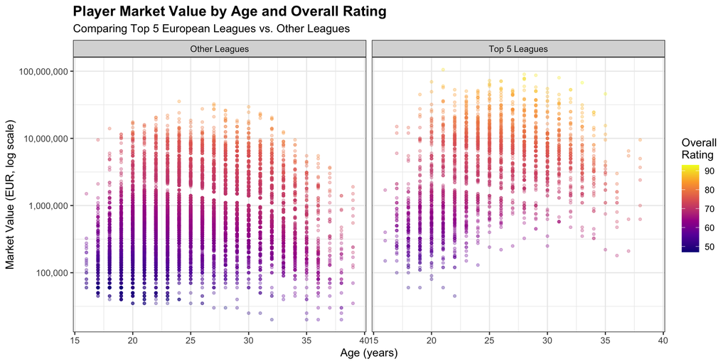

We can see several important patterns:

1. There is a strong positive relationship between overall rating (color) and market value across all ages: higher-rated players (yellow/orange points) systematically command higher values than lower-rated players (purple points).
2. Within each rating tier, market value follows an inverted-U pattern with age, peaking around ages 24-28 and declining thereafter, which reflects the typical career arc where players reach their physical and skill prime in their mid-20s.
3. Most strikingly, the Top 5 Leagues panel shows substantially higher market values at every age and rating level compared to Other Leagues: the median value in Top 5 leagues is €3.9 million versus only €550,000 in other leagues, a nearly seven-fold difference. This suggests that league prestige and economic power create a “valuation premium” independent of player quality.

## RQ2: Contextual & Positional Market Structure

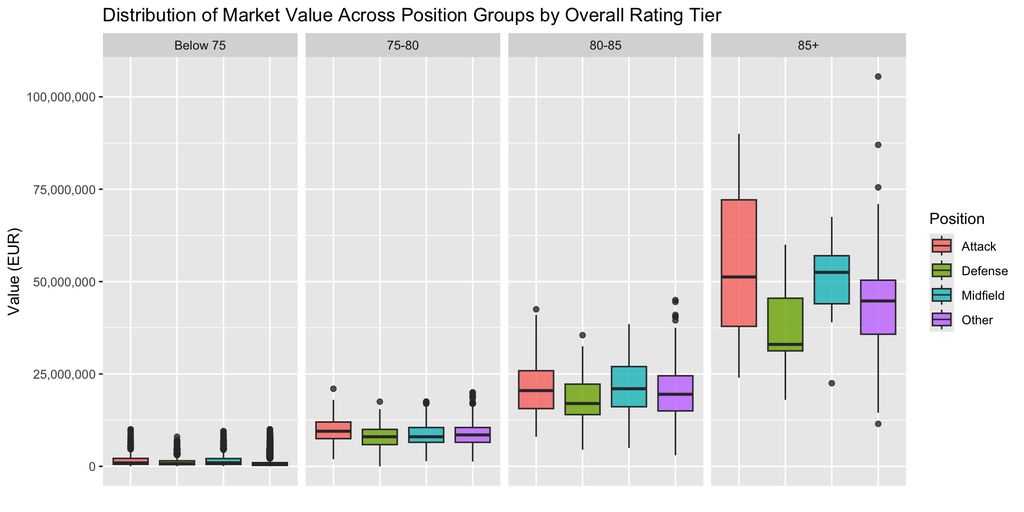

To further understand differences in market value across positions, we examine the supply of players at each specific playing position. The bar chart below shows the number of players in each player position, revealing substantial variation in positional supply.

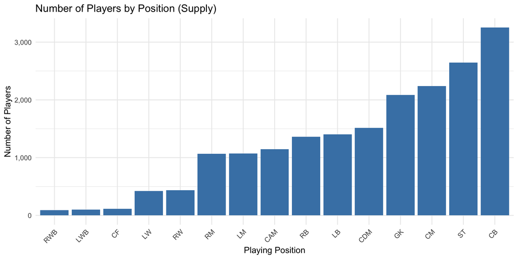

The bar chart shows that positional supply is far from uniform. Some attacking and wide positions, such as Centre Forward (CF), Left Winger (LW), Right Winger (RW), and the wing-back roles (RWB and LWB), have very small supply, meaning far fewer players naturally play these roles. In contrast, several central and defensive positions, such as Centre Back (CB), Striker (ST), Central Midfielder (CM), and Goalkeeper (GK), have much larger numbers of players, making them the most common positions in the dataset. This uneven distribution illustrates that certain positions are structurally scarce while others are saturated with players. This matters because positional supply can influence market value: positions with fewer available players may command higher prices simply due to scarcity, independent of overall player skill.

To evaluate how supply relates to market value, we plot the mean market value against the number of players in each position.

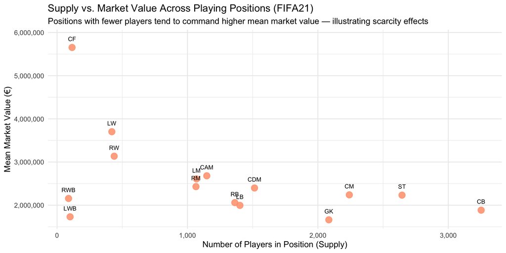

However, not all low-supply positions follow this pattern. Right Wing Backs (RWB) and Left Wing Backs (LWB) are notable exceptions: even though very few players occupy these positions, their average market values remain relatively low. This indicates that scarcity alone does not determine price. Wing-back roles, while tactically demanding, are often less central to team-building strategies and typically attract fewer high-profile players compared to scarce attacking roles. As a result, low supply in these positions does not translate to higher value. Overall, the pattern shows that while market scarcity generally increases value, positional importance and tactical demand also play critical roles in determining how much scarcity matters.

## RQ3: Technical Skill & Physical Skill Attributes

Quantitative metrics may never be able to fully answer what makes players great, but they can be of help determining what makes players valuable. FIFA uses dozens of metrics to rate players’ various abilities, and we can analyze how these metrics correlate with players’ value in an endeavor to pick out what attributes of on-field play drive player value.

For example, we might ask a question such as this: among forwards, how do two key attacking skills, shooting and dribbling, jointly relate to a player’s market value?

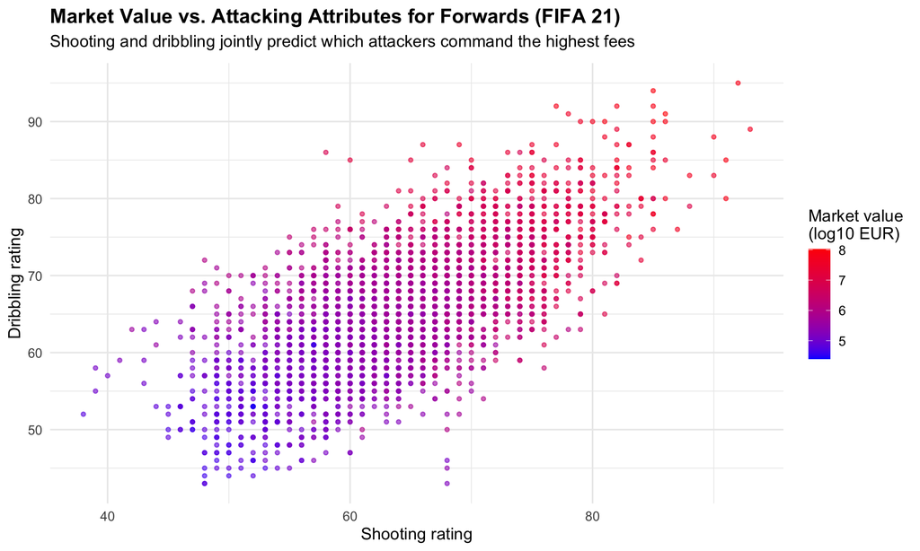

Each point in the plot represents a forward, the player’s shooting rating is represented on the x-axis, dribbling is represented on the y-axis, and the log10 market value in euros is represented on the color scale where blue = lower value and red = higher value. Players with low shooting and dribbling at the bottom left are almost entirely blue and purple, meaning low fees, while the top-right region which is high shooting and high dribbling is mostly red points, meaning the most high-cost attackers. This suggests a clear positive correlation between both attributes and value. There is a gradient at intermediate skill levels where higher dribbling tends to shift colors from cooler to warmer for a fixed shooting rating, and vice versa, meaning that both characteristics have a significant impact. The idea that clubs pay top prices mainly for forwards who are both strong on the ball and good finishers is supported by evidence from the observations that there are very few high-value players who only have one of the two skills.

This plot is particularly informative for our project goal of understanding how player attributes influence market value because it focuses on particular technical skills instead of an extensive overall rating within a single positional role. This figure examines which micro-level attacking attributes seem to drive those high valuations for forwards. It clearly demonstrates the 2D nature of the skill requirement and provides a specific hypothesis that we can test at a later phase of the project, such as interaction between shooting and dribbling in predicting market value.

While the first plot concentrates only on shooting and dribbling, forwards are evaluated on a wider range of attacking abilities in the next plot. We subsequently reduce five correlated attributes, which were: shooting, dribbling, pace, passing, and physique, into principal components and plot the first two PCs, further coloring points by log10 market value, to see how combinations of these ratings relate to value. This allows us to determine whether a single underlying attacking profile best explains why specific forwards are consistently more expensive than others.

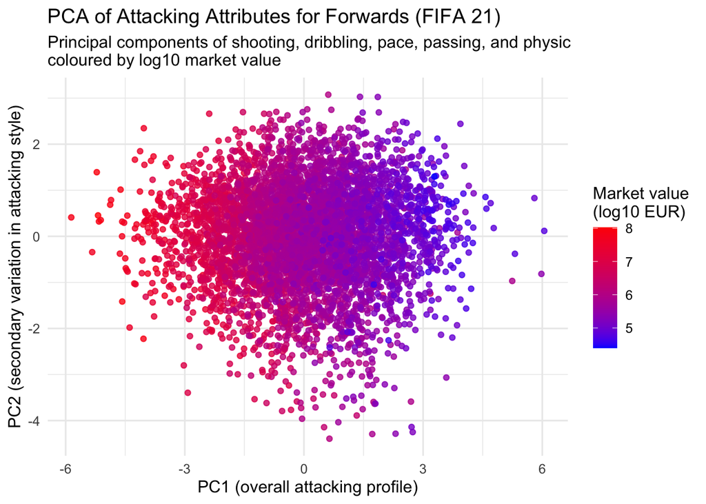

```
##
## Call:
## lm(formula = value_log10 ~ PC1, data = pca_forwards)
##
## Residuals:
##      Min       1Q   Median       3Q      Max
## -0.92331 -0.18129 -0.01381  0.16354  1.67183
##
## Coefficients:
##              Estimate Std. Error t value Pr(>|t|)
## (Intercept)  5.964057   0.003703  1610.8   <2e-16 ***
## PC1         -0.335800   0.002304  -145.7   <2e-16 ***
## ---
## Signif. codes:  0 '***' 0.001 '**' 0.01 '*' 0.05 '.' 0.1 ' ' 1
##
## Residual standard error: 0.2683 on 5250 degrees of freedom
## Multiple R-squared:  0.8018, Adjusted R-squared:  0.8017
## F-statistic: 2.123e+04 on 1 and 5250 DF,  p-value: < 2.2e-16
```

In the plot, every point is a forward. Players who are close to one another have similar combinations of shooting, dribbling, pace, passing, and physique because the x and y axes are the first two principal components from a PCA of five attacking attributes. The log10 of a player’s market value in euros is shown in color, with red representing higher value players and blue representing lower value players. Additionally, there is a distinct gradient along PC1 where the left end of the axis is dominated by red points, meaning that forwards with that specific combination of attacking skills are consistently the most expensive. In contrast, the opposite end of PC1 consists mainly of blue and purple points, indicating that the forwards are cheaper. Market value does not fluctuate as systematically along PC2 compared to how it does along PC1, meaning that the first component is the primary direction that relates to value. PC2 captures secondary variation in attacking style, so players spread vertically.

We fit a simple linear regression model with log10 market value as the response and PC1 score as the predictor to formally test whether the overall attacking profile from the PCA is related to forwards’ value: $\log_{10}(\text{value}) = 5.96 - 0.34 \cdot \mathrm{PC1}$. The null hypothesis is $H_0:\ \beta_{\mathrm{PC1}} = 0$, i.e. no relationship between PC1 and value, versus the alternative hypothesis $H_A:\ \beta_{\mathrm{PC1}} \neq 0$. According to the model output, PC1’s estimated slope is $\hat{\beta}_{\mathrm{PC1}} = -0.336$ with standard error 0.0023. This results in a t-statistic of t = − 145.7 on 5250 df and a p-value < 0.0001. Therefore, we reject the null hypothesis H0 and conclude that PC1 is significantly correlated with the market value of forwards. Our interpretation that the main composite attacking skill dimension (PC1) is an important contributor to player value is reinforced by the model R² = 0.80, which means that this single principal component accounts for around 80% of the variation in log10 market value.

This PCA plot is informative for our project because it simplifies multiple correlated ratings into two interpretable dimensions and lets us observe how player value operates across the entire attacking skill space. Instead of being limited to a few raw attributes, this PCA plot is useful for our project goal. It shows that high market value does not correspond to a single rating but to a specific joint profile across multiple attacking skills, which can be further formalized by examining PCA loadings or applying PC scores as predictors in a value model. Additionally, the visualization yields a specific hypothesis for the project. In addition to the overall rating, the first principal component of attacking attributes is responsible for a significant portion of the variation in forwards’ market values.

In the last plot, we expanded our set of metrics to encompass more of players’ skill evaluations and used dimensionality reduction to capture the more complex evaluation in an interpretable way. Yet dimensionality reduction allows us to use an arbitrary number of variables, meaning we can expand our metrics even further. Here, we predict player value, measured by wage, using FIFA’s more advanced metrics, which evaluate even finer parts of players’ game, like agility, aggression, and ball control.

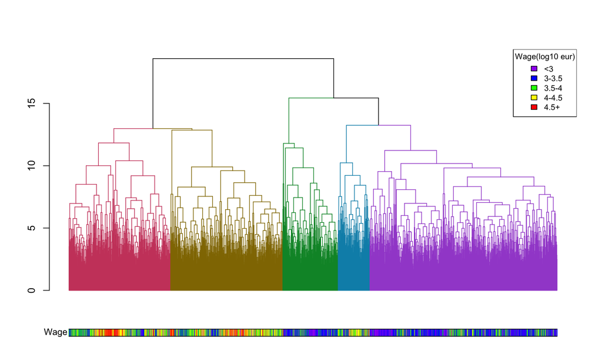

In this plot, we cluster all defenders in FIFA 21 using FIFA’s advanced metrics. Then, by comparing the clusters produced by multi-demensional scaling on these attributes with players’ wages, sorted into the same number of groups, we can evaluate how well FIFA’s metrics predict player wage. We can see that the clusters in the dendrogram tend to align with a wage group; the first two clusters contain almost all of the highest-earning defenders, while the lowest-paid players are sorted into the third and fifth clusters, with many middle-wage players in the fourth cluster. This plot gives us a large-scale evaluation of how good FIFA’s metrics are at predicting a player’s value, and we find that the advanced metrics are decent predictors. This tells us that, while not perfect, FIFA’s metrics are useful for evaluating players’ abilities, and that these evaluations have a relevant relationship with the market’s valuation.

## Conclusion

In this project we used the FIFA 21 player dataset to investigate how market value tracks player demographics, league context, positional role, and technical/physical skill profiles.

In research question 1, we learned that nationality, age and league all have an effect on player value. We saw that many nations have a very high mean player value, but that median player value is much lower in many places, indicating a large effect from superstar players. Some less affected regions include eastern Europe and northern Africa, indicating a higher median quality but fewer superstars. Then we turned to age, investigating how it affects market value. We learned that player age can temper the effects of physical ability on market value, indicating a greater dependence on skill among older players rather than physicality. Finally, we looked at age and overall rating in conjunction with player league. We found that players in the top leagues had higher values in general than those in other leagues, and also clarified the age-value relationship to be a curve which peaks in the mid-to-late twenties, with the highest-valued players also having the highest overall rating. Using demographics, we were able to describe trends in player value using easy-to-find information with no subjectivity.

In research question 2, we investigated player positional roles. We found that all positions are not valued equally, with attacking and midfield players typically valued higher than defenders. Then, we looked at the supply of players available at each position, finding sharp differences in how many players are available among positions. Using this information, we found that supply is generally slightly negatively related to value, but that this effect is driven in large part by center forwards, who are in low supply and have a massive average market value. This plot combined with the first demonstrated that positional preference for attacking players like center forwards and left and right wings, who also had higher average market values, are not simply the result of supply and demand, since other positions had similar supply and lower demand. Therefore we can conclude player positions intrinsically influence value, with offensive players being higher valued than defensive players.

In research question 3, we examined how FIFA’s player evaluation metrics predict player value, finding that many metrics prove to have strong predictive power. A small sample of two metrics showed a clear positive relation with market value when those two metrics increased, and increasing the number of metrics to include five major metrics resulted in a strong model. Using dimensionality reduction on those five metrics, we were able to explain 80% of variance in market value for players at the forward position. Using all of FIFA’s metrics relevant to defenders, we were also able to show that performing dimensionality reduction on advanced metrics produces groups aligned with player wages. Thus we demonstrated that FIFA’s metrics are good for predicting value, which shows that using individual player skills is a strong method for value assessment.

Using our takeaways from these three research questions, we conclude that valuation is simultaneously global, individual, and contextual. Demographics play no small role, and individual skillsets are also strong predictors of value. Yet knowing players’ positional and league situations are also necessary to fully understand their valuations.

## Limitations & Further Research

Although this report provides meaningful insights into the drivers of player market valuation in FIFA 21, several limitations should be acknowledged. First, FIFA21 market values are estimates produced within a video-game system rather than real transfer fees, meaning they may not fully capture real-world market dynamics. Second, because the dataset covers only a single season, we cannot observe how valuation changes over time or how career trajectories affect value. Third, several variables in the dataset, such as detailed positions or league tiers, were simplified for interpretability, which may obscure more granular patterns. Finally, many player attributes are highly correlated, making it difficult to assess their independent contributions to market value without more advanced modeling.

A related direction for future research involves identifying which variables most strongly predict market value. While our visual analysis reveals clear relationships, determining the relative importance of demographic, positional, contextual, and technical factors is challenging because the dataset contains both categorical and quantitative variables. Simple regression models can quantify the influence of continuous variables, but capturing interactions between categorical and continuous factors (or understanding how clusters of attributes jointly shape value) requires more sophisticated statistical or machine-learning techniques. Exploring these predictive relationships using multivariate regression, regularization methods, or tree-based models would help build a deeper and more quantitative understanding of how player attributes translate into market valuation.

Future work could also extend the analysis using the full FIFA 15–21 dataset, enabling longitudinal modeling of how players develop, how market values shift across seasons, and how changes in leagues, positions, or attributes influence value over time. Incorporating multiple years of data would provide richer insight into career trajectories, aging patterns, and long-term market dynamics that cannot be captured in a single-season snapshot.